# Estudis d'Informàtica, Multimédia i Telecomunicacions

# Mineria de dades - PAC5 - Models Agregació

Novembre 2018

# 1 Introducció

## 1.1 Presentació

Aquesta Prova d’Avaluació Continuada cobreix els mòduls 6 i 8 (Avaluació de Models) del programa de l’assignatura.

## 1.2 Competències

Les competències que es treballen en aquesta prova són:

- Ús i aplicació de les TIC en l’àmbit acadèmic i professional
- Capacitat per innovar i generar noves idees.
- Capacitat per avaluar solucions tecnològiques i elaborar propostes de projectes tenint en compte els recursos, les alternatives disponibles i les condicions de mercat.
- Conèixer les tecnologies de comunicacions actuals i emergents i saber-les aplicar convenientment per a dissenyar i desenvolupar solucions basades en sistemes i tecnologies de la informació.
- Aplicació de les tècniques específiques d’enginyeria del programari a les diferents etapes del cicle de vida d’un projecte.
- Capacitat per aplicar les tècniques específiques de tractament, emmagatzematge i administració de dades.
- Capacitat per proposar i avaluar diferents alternatives tecnològiques per a resoldre un problema concret.

## 1.3 Objectius

La correcta assimilació del Mòdul 6. En aquesta PAC treballarem la generació, interpretació i avaluació d’un model on generarem regles d’associació amb el programari de pràctiques. No perdrem de vista les fases de preparació de les dades, qualitat del model i extracció inicial de coneixement.

## 1.5 Recursos Bàsics

**Material docent proporcionat por la UOC.**

Mòdul 6 i 8 del material didàctic.

## 1.6 Criteris de valoració

**Exercicis teòrics**

Tots els exercicis han de ser presentats de forma raonada i clara, especificant tots i cadascun dels passos que s’hagin dut a terme per a la seva resolució. No s’acceptarà cap resposta que no estigui clarament justificada.

**Exercicis pràctics**

Per a totes les PAC és necessari documentar en cada apartat de l’exercici pràctic què s’ha fet i com s’ha fet, quin era l’objectiu i com s’ha desenvolupat.

## 1.7 Format i data d’entrega

El format de lliurament és: usernameestudiant-PACn.doc/docx/odt/pdf Data de lliurament: 05/12/2018 Cal lliurar la PAC a la bústia de lliuraments de l’aula

## 1.8 Nota: Propietat intel·lectual

> Sovint és inevitable, al produir una obra multimèdia, fer ús de recursos creats per terceres persones. És per tant comprensible fer-lo en el marc d’una pràctica dels Estudis, sempre que això es documenti clarament i no suposi plagi en la pràctica.

> Per tant, al presentar una pràctica que faci ús de recursos aliens, s’ha de presentar juntament amb ella un document en que es detallin tots ells, especificant el nom de cada recurs, el seu autor, el lloc on es va obtenir i el seu estatus legal: si l’obra està protegida pel copyright o s’acull a alguna altra llicència d’ús (Creative Commons, llicència GNU, GPL …). L’estudiant haurà d’assegurar-se que la llicència no impedeix específicament el seu ús en el marc de la pràctica. En cas de no trobar la informació corresponent haurà d’assumir que l’obra està protegida per copyright. Hauríeu a més, d’adjuntar els fitxers originals quan les obres utilitzades siguin digitals, i el seu codi font si correspon

> Un altre punt a considerar és que qualsevol pràctica que faci ús de recursos protegits pel copyright no podrà en cap cas publicar-se en Mosaic, la revista del Graduat en Multimèdia de la UOC, llevat que els propietaris dels drets intel·lectuals donin la seva autorització explícita

# 2 Exemple

En aquest exemple treballarem amb l’algoritme “apriori” per a obindre regles d’associació a paritr d’un data sert definit. Aqueste regles ens audaran a comprendre la informació continguda, i de com es relaciona entre si.

```r
url <- "http://archive.ics.uci.edu/ml/machine-learning-databases/adult/adult.data"
copy <- read.table(file=url, header=FALSE, sep=",", na.strings="?", dec=".", strip.white=TRUE)
data <- copy
columns <- c("age","workclass","fnlwgt","education","education-num","marital-status","occupation","relationship","race","sex","capital-gain","capital-loss","hour-per-week","native-country","income")
names(data) <- columns
```

De cara a la practicitat del exemple eliminarem un conjunt de columnes que no aporten gaire valor

```r
data$fnlwgt <- NULL
data$`hour-per-week` <- NULL
data$`capital-gain` <- NULL
data$`capital-loss` <- NULL
```

I factoritzem aquelles columnes que no ho son

```r
data$age <- as.factor(data$age)
data$`education-num` <- as.factor(data$`education-num`)

summary(data)
```

```
##       age                   workclass            education
##  36     :  898   Private         :22696   HS-grad     :10501
##  31     :  888   Self-emp-not-inc: 2541   Some-college: 7291
##  34     :  886   Local-gov       : 2093   Bachelors   : 5355
##  23     :  877   State-gov       : 1298   Masters     : 1723
##  35     :  876   Self-emp-inc    : 1116   Assoc-voc   : 1382
##  33     :  875   (Other)         :  981   11th        : 1175
##  (Other):27261   NA's            : 1836   (Other)     : 5134
##  education-num                 marital-status            occupation
##  9      :10501   Divorced             : 4443   Prof-specialty : 4140
##  10     : 7291   Married-AF-spouse    :   23   Craft-repair   : 4099
##  13     : 5355   Married-civ-spouse   :14976   Exec-managerial: 4066
##  14     : 1723   Married-spouse-absent:  418   Adm-clerical   : 3770
##  11     : 1382   Never-married        :10683   Sales          : 3650
##  7      : 1175   Separated            : 1025   (Other)        :10993
##  (Other): 5134   Widowed              :  993   NA's           : 1843
##          relationship                   race           sex
##  Husband       :13193   Amer-Indian-Eskimo:  311   Female:10771
##  Not-in-family : 8305   Asian-Pac-Islander: 1039   Male  :21790
##  Other-relative:  981   Black             : 3124
##  Own-child     : 5068   Other             :  271
##  Unmarried     : 3446   White             :27816
##  Wife          : 1568
##
##        native-country    income
##  United-States:29170   <=50K:24720
##  Mexico       :  643   >50K : 7841
##  Philippines  :  198
##  Germany      :  137
##  Canada       :  121
##  (Other)      : 1709
##  NA's         :  583
```

El procès d’anàlisi de dades, especialment de cara als nous datasets, ha d’incloure un anàlisi visual. Donat que estem fent servir un dataset amb el que ja hem treballat, i no aportaria tan de valor com a exemple, ens saltarem aquesta part.

```r
# install.packages("arules")
library(arules)

# binarizamos los datos
mba <-as(data,"transactions")

summary(mba)
```

```
## transactions as itemMatrix in sparse format with
##  32561 rows (elements/itemsets/transactions) and
##  190 columns (items) and a density of 0.05720583
##
## most frequent items:
## native-country=United-States                   race=White
##                        29170                        27816
##                 income=<=50K            workclass=Private
##                        24720                        22696
##                     sex=Male                      (Other)
##                        21790                       227717
##
## element (itemset/transaction) length distribution:
## sizes
##     8     9    10    11
##    27  1809   563 30162
##
##    Min. 1st Qu.  Median    Mean 3rd Qu.    Max.
##    8.00   11.00   11.00   10.87   11.00   11.00
##
## includes extended item information - examples:
##   labels variables levels
## 1 age=17       age     17
## 2 age=18       age     18
## 3 age=19       age     19
##
## includes extended transaction information - examples:
##   transactionID
## 1             1
## 2             2
## 3             3
```

Podem observar que s’han generat 32561 transaccinos, cadascuna d’elles amb 190 columnes. I podem veure els elements més comuns, com ara: native-country = United-States, workclass = Private o race = White.

La representació gràfica, seria:

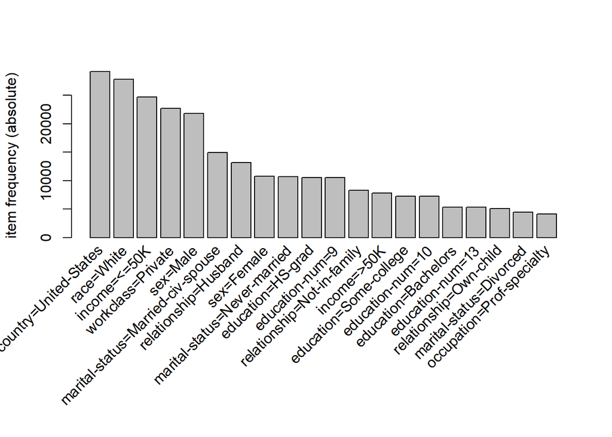

```r
itemFrequencyPlot(mba,topN=20,type="absolute")
```

Seleccionem un nivell de suport del 5% i una confiança del 95%. Amb lo primer conseguim que cadascuna de les regles estigui present al menys el 5% de les mostres, lo que els hi otorga representativitat, mentres que amb lo segon obtenim la probabilitat de que les regles siguin certes a les mostres en les que els seus antecedents són certs també.

```r
rules <- apriori(mba, parameter = list(supp = 0.05, conf = 0.95))
```

```
## Apriori
##
## Parameter specification:
##  confidence minval smax arem  aval originalSupport maxtime support minlen
##        0.95    0.1    1 none FALSE            TRUE       5    0.05      1
##  maxlen target   ext
##      10  rules FALSE
##
## Algorithmic control:
##  filter tree heap memopt load sort verbose
##     0.1 TRUE TRUE  FALSE TRUE    2    TRUE
##
## Absolute minimum support count: 1628
##
## set item appearances ...[0 item(s)] done [0.00s].
## set transactions ...[190 item(s), 32561 transaction(s)] done [0.03s].
## sorting and recoding items ... [32 item(s)] done [0.00s].
## creating transaction tree ... done [0.03s].
## checking subsets of size 1 2 3 4 5 6 7 8 9 done [0.02s].
## writing ... [1523 rule(s)] done [0.00s].
## creating S4 object  ... done [0.00s].
```

S’han obtngut 1523 regles, les quals ordenem i visualitzem per a una millor comprensió.

```r
rules <- sort(rules, by="confidence", decreasing=TRUE)
inspect(rules[1:10], ruleSep = "---->", itemSep = " + ", setStart = "", setEnd ="", linebreak = FALSE)
```

```
##      lhs
## [1]  education=Masters                                 ---->
## [2]  education-num=14                                  ---->
## [3]  education=Bachelors                               ---->
## [4]  education-num=13                                  ---->
## [5]  education=Some-college                            ---->
## [6]  education-num=10                                  ---->
## [7]  education-num=9                                   ---->
## [8]  education=HS-grad                                 ---->
## [9]  occupation=Exec-managerial + relationship=Husband ---->
## [10] occupation=Exec-managerial + relationship=Husband ---->
##      rhs                               support    confidence lift
## [1]  education-num=14                  0.05291607 1          18.897853
## [2]  education=Masters                 0.05291607 1          18.897853
## [3]  education-num=13                  0.16446055 1           6.080486
```

[output cut: 18 more lines]

Així doncs, veiem que si el nivell d’educació és Màster, el nombre d’anys que s’han estudiat son 14, o que si la ocupació principal es de mànager executiu i la presona té la relació “husband” és que el seu génere es masculí. Donat això, ens preguntem si aquestes regles ens dona alguna informació útil. La resposta és que de fet no. La relació entre els anys dedicats al estudi i el nivell acadèmic és obvia i el víncle entre l’estat civil i el tipus de relació també és trivial. Per què les regles més representatives donen informació fàcilment deribable? Precisament perque són aquetes relacions les que són més frequents en el conjunt de dades, i és per això que afloren com a regles d’associació amb un lift elevat.

Podem forçar apriori er a que ens doni algo més significatiu, com aquelles regles que impliquin que el income sigui més petit que 50K i la rasa sigui blanca

```r
rules <- apriori(mba, parameter=list(supp=0.01, conf=0.85), appearance=list(default="lhs",rhs=c("income=<=50K", "race=White")), control=list(verbose=F))

summary(rules)
```

```
## set of 5895 rules
##
## rule length distribution (lhs + rhs):sizes
##    1    2    3    4    5    6    7    8    9   10
##    1   90  664 1543 1752 1202  501  124   17    1
##
##    Min. 1st Qu.  Median    Mean 3rd Qu.    Max.
##   1.000   4.000   5.000   4.916   6.000  10.000
##
## summary of quality measures:
##     support          confidence          lift            count
##  Min.   :0.01001   Min.   :0.8501   Min.   :0.9951   Min.   :  326
##  1st Qu.:0.01207   1st Qu.:0.8935   1st Qu.:1.0532   1st Qu.:  393
##  Median :0.01701   Median :0.9253   Median :1.0962   Median :  554
##  Mean   :0.02819   Mean   :0.9265   Mean   :1.1302   Mean   :  918
##  3rd Qu.:0.02865   3rd Qu.:0.9579   3rd Qu.:1.2242   3rd Qu.:  933
##  Max.   :0.85427   Max.   :1.0000   Max.   :1.3172   Max.   :27816
##
## mining info:
##  data ntransactions support confidence
##   mba         32561    0.01       0.85
```

```r
rules <- sort(rules, by="lift", decreasing=TRUE)
inspect(rules[1:10], ruleSep = "---->", itemSep = " + ", setStart = "", setEnd ="", linebreak = FALSE)
```

```
##      lhs                                         rhs          support
## [1]  age=17                                ----> income=<=50K 0.01213108
## [2]  age=18                                ----> income=<=50K 0.01689137
## [3]  age=20                                ----> income=<=50K 0.02312583
## [4]  age=17 + relationship=Own-child       ----> income=<=50K 0.01102546
## [5]  age=17 + marital-status=Never-married ----> income=<=50K 0.01206965
## [6]  age=17 + native-country=United-States ----> income=<=50K 0.01148613
## [7]  age=18 + relationship=Own-child       ----> income=<=50K 0.01428089
## [8]  age=18 + marital-status=Never-married ----> income=<=50K 0.01655355
## [9]  age=18 + workclass=Private            ----> income=<=50K 0.01268389
## [10] age=18 + native-country=United-States ----> income=<=50K 0.01609287
##      confidence lift     count
## [1]  1          1.317193 395
## [2]  1          1.317193 550
## [3]  1          1.317193 753
## [4]  1          1.317193 359
## [5]  1          1.317193 393
## [6]  1          1.317193 374
## [7]  1          1.317193 465
## [8]  1          1.317193 539
## [9]  1          1.317193 413
## [10] 1          1.317193 524
```

# 3 Enunciat

Contextualitzeu els exemples de les següents preguntes respecte al projecte que heu definit a la PAC1. Si ho desitgeu, podeu redefinir o afinar el projecte.

## 3.1 Exercici 1:

Creieu que les regles d’associació són el mètode més adequat per aconseguir els objectius que us havíeu proposat? Justifiqueu la resposta tot raonant-la. Com podria ser el model resultant? Doneu un exemple de la interpretació que es podria derivar del model generat

## 3.2 Exercici 2:

En aquest exercici seguireu els passos del cicle de vida d’un projecte de mineria de dades pel cas d’un algorisme de generació de regles d’associació. Ho fareu amb el fitxer Lastfm.csv que trobareu a la wiki. Aquest fitxer conté un conjunt de registres. Aquests registres són l’històric de les cançons que ha escoltat un usuari («user») en un portal Web de musica. «artist» és el nom del grup que ha escoltat, «sex» i «country» es corresponen a variables que descriuen a l’usuari.

## 3.3 Exercici 3:

Repetiu l’exercici 2 amb algun altre conjunt de dades. Poden ser dades reals del vostre àmbit laboral o d’algun repositori de dades a Internet. Mireu per exemple: http://www.ics.uci.edu/~mlearn/MLSummary.html Compte amb les dades, heu de tenir present la teoria vista perquè l’exercici tingui sentit. Seguiu el guió de la pregunta anterior. Els passos per binaritzar poden ser diferents en funció de les dades, no els prengueu com un dogma. De fet a R hi ha paquets per fer-ho.

# 4 Rúbrica

## 4.1 Exercici 1

- 20%. S’explica de forma clara si l’ús de mètodes d’agregació és l’adequat per a aconseguir els objectius proposats en el cas plantejat a la PAC1. Si no ho és, es proposa un cas on si ho es.

## 4.2 Exercici 2

- 5%. Es realitza un resumen de les dades incloses a la base de dades.
- 5%. Es preparen les dades de forma correcta.
- 10%. S’aplica l’algoritme de regles d’associació.
- 10%. S’expliquen les conclussions que s’obtenen.
- 5%. Es realitzen diferents proves variant alguns paràmetres.
- 5%. Es presenta el códi i és fàcilmente reproduible.

## 4.3 Exercici 3

- 5%. Es realitza un resumen de les dades incloses a la base de dades.
- 5%. Es preparen les dades de forma correcta.
- 10%. S’aplica l’algoritme de regles d’associació.
- 10%. S’expliquen les conclussions que s’obtenen.
- 5%. Es realitzen diferents proves variant alguns paràmetres.
- 5%. Es presenta el códi i és fàcilmente reproduible.